# W271 Summer 2022 Lecture Video Question Solutions Week 1

## 2.6 An Example

### Q: Based on the model provided, answer the following questions: compute the predicted probability when change=0.5 and distance=50 and using this estimated model plot the estimated probability (of success) curve.

#### Solution:

```r
# data can be downloaded from https://www.chrisbilder.com/categorical/programs_and_data.html
df <- read.csv("~/Documents/Berkeley W271/Week 2 Discrete Response Model Part 2/Placekick.csv",
               stringsAsFactors = F)

glm.model <- glm(formula = good ~ change + distance, family = binomial(link = logit),
                 data = df)

summary(glm.model)
```

```
##
## Call:
## glm(formula = good ~ change + distance, family = binomial(link = logit),
##     data = df)
##
## Deviance Residuals:
##     Min       1Q   Median       3Q      Max
## -2.7061   0.2282   0.2282   0.3750   1.5649
##
## Coefficients:
##              Estimate Std. Error z value Pr(>|z|)
## (Intercept)  5.893181   0.333184  17.687   <2e-16 ***
## change      -0.447783   0.193673  -2.312   0.0208 *
## distance    -0.112889   0.008444 -13.370   <2e-16 ***
## ---
## Signif. codes:  0 '***' 0.001 '**' 0.01 '*' 0.05 '.' 0.1 ' ' 1
##
## (Dispersion parameter for binomial family taken to be 1)
##
##     Null deviance: 1013.4  on 1424  degrees of freedom
## Residual deviance:  770.5  on 1422  degrees of freedom
## AIC: 776.5
##
## Number of Fisher Scoring iterations: 6
```

1. Compute the predicted probability when change=0.5 and distance=50.

```r
new.data <- data.frame("change" = 0.5, "distance" = 50)

pred.prob <- predict(glm.model, newdata = new.data, type = "response")

print(paste("P(good | change = 0.5, distance = 50) = ", round(pred.prob, 2), sep = ""))
```

```
## [1] "P(good | change = 0.5, distance = 50) = 0.51"
```

2. Plot the estimated probability (of success) curve

We will fix change=0.5 for simplicity and plot the probability as a function of distance.

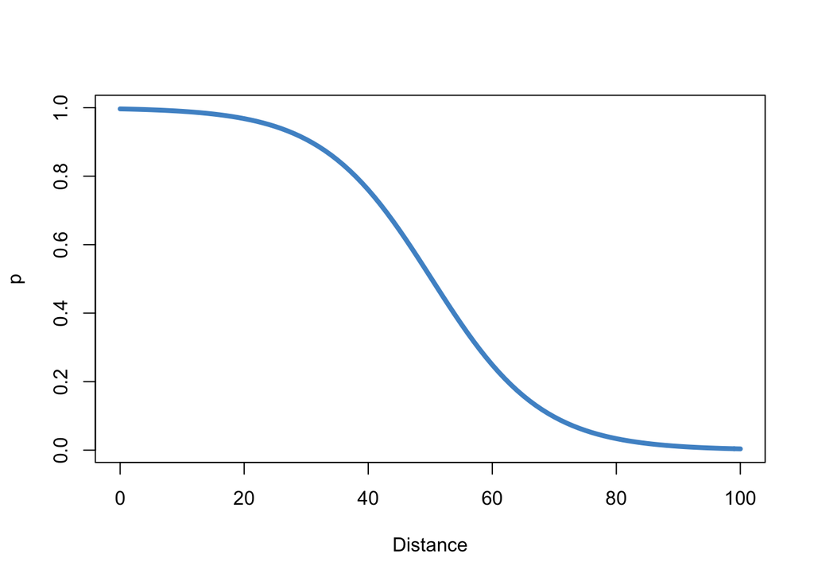

```r
# distance is in yards and a football field ranges from 0 to 100 yards
new.data <- data.frame("change" = 0.5, "distance" = 0:100)

pred.prob <- predict(glm.model, newdata = new.data, type = "response")

par(mfrow=c(1,1))
plot(x = new.data$distance, y = pred.prob, lwd = 4, col = "steelblue3",
     xlab = "Distance", ylab = "p", type = "l")
```

## 2.10 Odds Ratios

### Q: Verify that the odds ratio form in the logistic regression model.

#### Solution:

Remember that the odds ratio $OR=\frac{P(y=1|x_r=x+c)/P(y=0|x_r=x+c)}{P(y=1|x_r=x)/P(y=0|x_r=x)}$.

$log(\frac{P(y=1|x_r=x+c)}{P(y=0|x_r=x+c)})=\beta_0+\beta_1*0+...+\beta_r*(x+c)+..+\beta_p*0=\beta_r(x+c)$

$\frac{P(y=1|x_r=x+c)}{P(y=0|x_r=x+c)}=e^{\beta_r(x+c)}$

$log(\frac{P(y=1|x_r=x)}{P(y=0|x_r=x)})=\beta_0+\beta_1*0+...+\beta_r*x+..+\beta_p*0=\beta_rx$

$\frac{P(y=1|x_r=x)}{P(y=0|x_r=x+c)}=e^{\beta_rx}$

**$OR=\frac{e^{\beta_r(x+c)}}{e^{\beta_rx}}=e^{\beta_r(x+c)-\beta_rx}=e^{\beta_rc}$**

## 2.12 Visual Assessment of the Logistic Regression Model

### Q: What do you think about the fit of the model in the provided plot?

#### Solution:

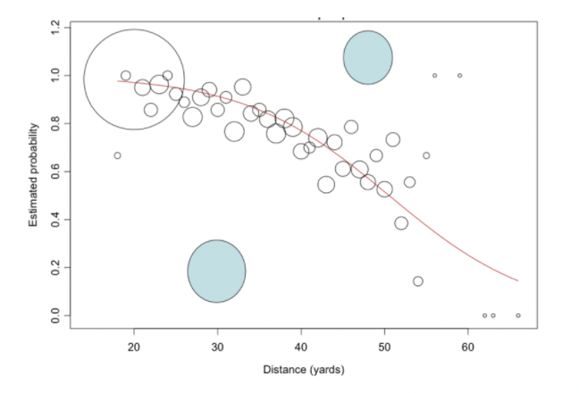

The above plot shows the fitted probabilities from the glm model as a function of distance in red. We see various sized circles based on the frequency of observations at that distance.